# MITx:15.071x_U1-Recitation-Creating_Plots-_in_R

Rahul Yadav

April 13, 2016

# Outline:

#### Visualization is a crucial step for initial data exploration. It helps us discern relationships, patterns, and outliers.

## Creating Scatter Plots.

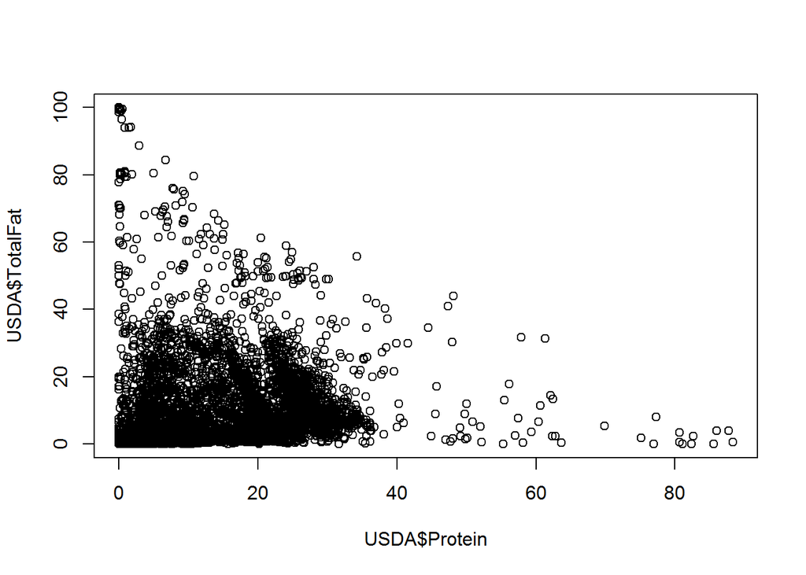

```r
USDA <- read.csv("C:/Users/pySag/Desktop/MITx15.071x/Datasets/USDA.csv")
plot( USDA $ Protein, USDA $ TotalFat )
```

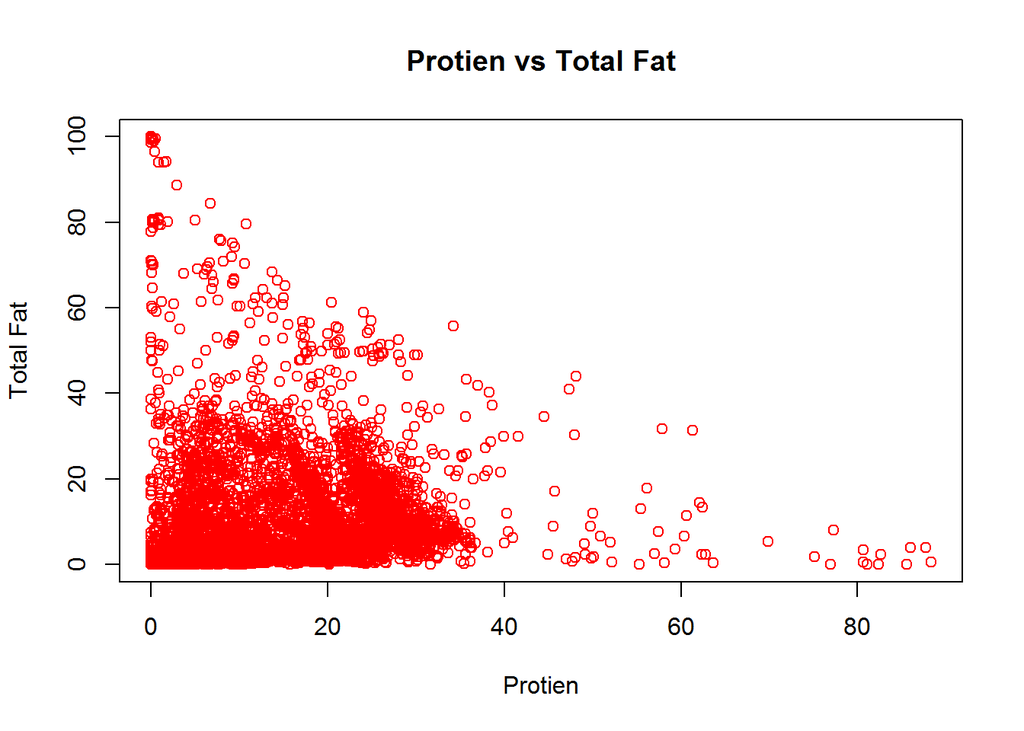

```r
# Improving our data visualization with "Labels"
plot( USDA $ Protein, USDA $ TotalFat, xlab = "Protien", ylab = "Total Fat", main = "Protien vs Total Fat", col = "red")
```

## Creating Histograms.

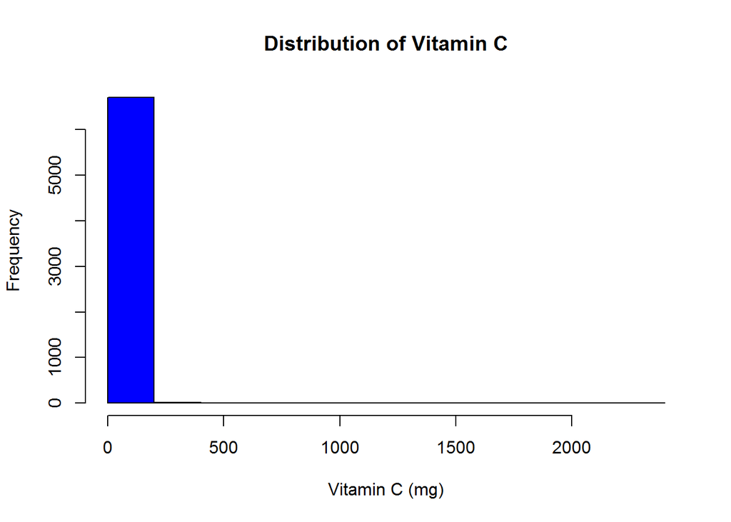

```r
# [Note]: histogram function only takes "1 argument", becuase y axis should have the frequencies to exist on the first place.
hist( USDA $ VitaminC, xlab = "Vitamin C (mg)", main = "Distribution of Vitamin C", col = "blue" )
```

```r
# Improving our histogram
```

### The following are the observations gathered form the histogram:

#### Our histogram function lumps them all into “1 cell or bin”.

#### We want to “zoom-in” to get finer understanding of the data.

#### To do this, we have to limit “x-axis” to go from 0 to 100 mgs.

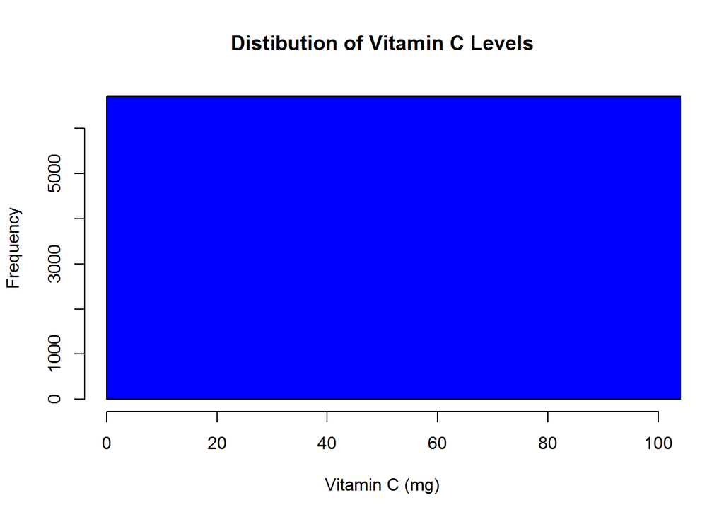

```r
hist( USDA $ VitaminC, xlab = "Vitamin C (mg)", main = "Distibution of Vitamin C Levels", col = "blue", xlim = c(0, 100) )
```

#### It turns out we got a histogram of one giant bin, we don’t want that.

#### It dosen’t break the cell in to smaller pieces.

#### We want 100 cells, and since the interval goes from 0 to 100,

#### We would expect, R to break division into 1 mg each.

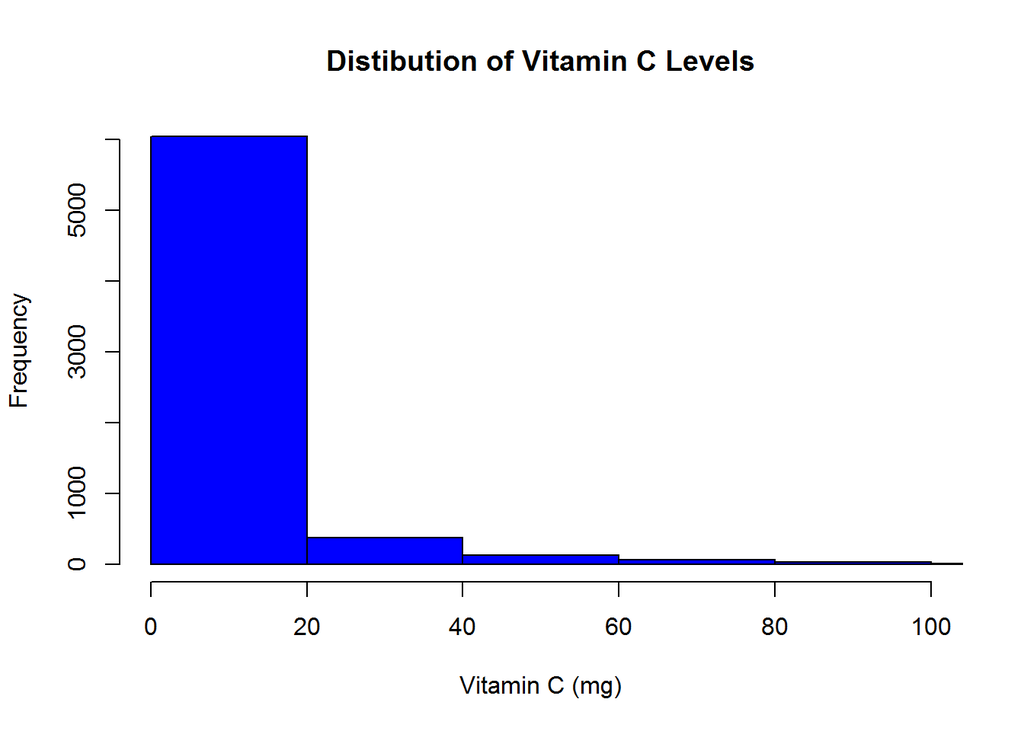

```r
hist( USDA $ VitaminC, xlab = "Vitamin C (mg)", main = "Distibution of Vitamin C Levels", col = "blue", xlim = c(0, 100), breaks = 100 )
```

#### What happend? we were expecting 100 cells!

#### Well, if we look closely, out histogram exceeded the 100 limiter mark.

#### Now, 1 big bin of 2000 cell was divided by 100, 20mg chunks. (2000 /100) = 20!

#### Hence to fix this, we will divide a cell of 2000 bin by 2000 individual bins of 1 mg each.

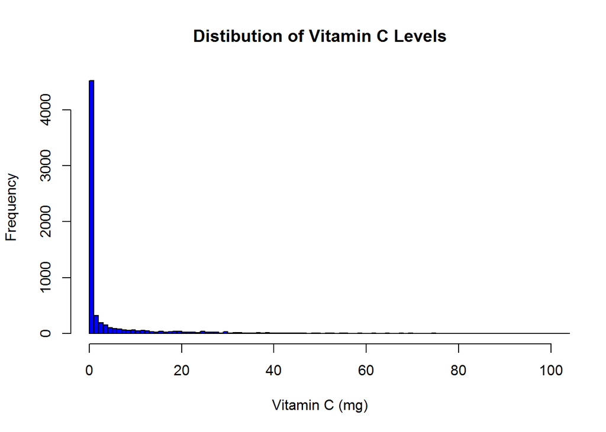

```r
hist( USDA $ VitaminC, xlab = "Vitamin C (mg)", main = "Distibution of Vitamin C Levels", col = "blue", xlim = c(0, 100), breaks = 2000 )
```

## Creating Box Plots.

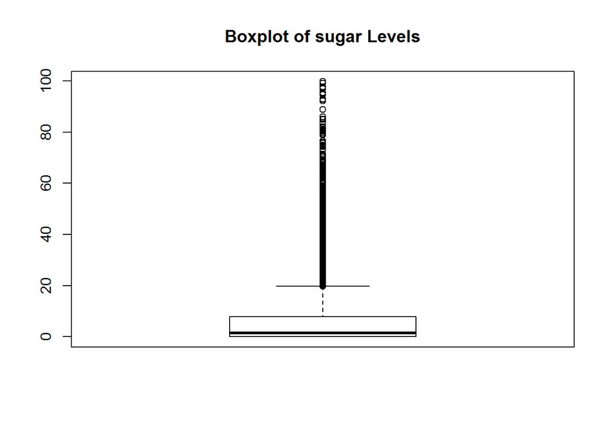

```r
# Note: Boxplot also utilizes only single argument( a vector ).
boxplot( USDA $ Sugar, main = "Boxplot of sugar Levels")
```

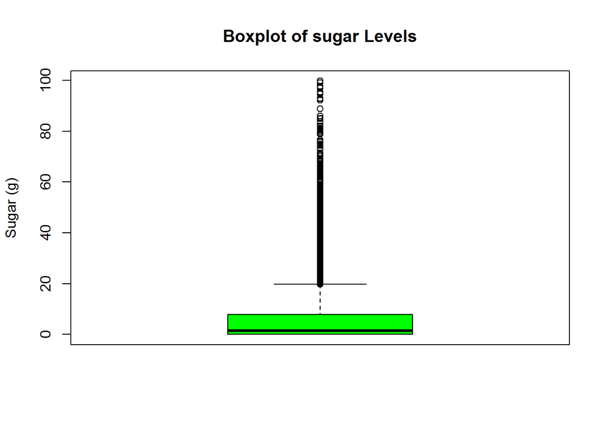

```r
# If we aren't sure of the label, simply run the code and check to see if y-axis is labelled.
boxplot( USDA $ Sugar, main = "Boxplot of sugar Levels", ylab = "Sugar (g)", col = "green")
```

#### Inference from our boxplot.

#### There exist some food that almost have 100 gm of sugar!